# Home Work 2

’Joba Adisa

2022-09-18

```r
# Loading libraries
library(dataedu)
library(tidyverse)
library(sjPlot)

# Reading Data files
dat <- read_csv("data/dat.csv")
measure_mean <- read_csv("data/measure_mean.csv")
survey_responses <- read_csv("data/survey_responses.csv")
```

## Exercise 1

The graph below shows a bar chart distribution of the means of the different measures in the student surveyUsing ggplot to create a bar chart comparing the survey subscale means in the measure_mean data file

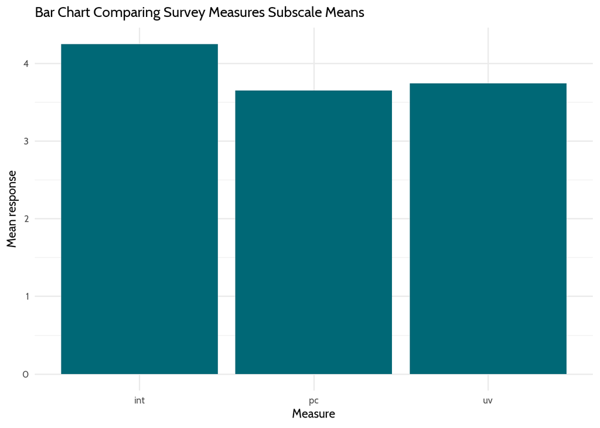

Fig. 1: Mean distribution of survey measures

```r
measure_mean %>%
  ggplot(aes(x = measure, y = mean_response)) +
  # draw the plot
  geom_bar(stat = "Identity", fill = dataedu_colors("turquoise")) +
  theme_dataedu() +
  labs(title = "Bar Chart Comparing Survey Measures Subscale Means",
       x = "Measure", y = "Mean response") +
  theme(text = element_text(size = 20))
```

## Exercise 2

### The Relationship between Time Spent on Course and Final Grade

The plot below shows the relationship between the time spent by students in a course and their final grade in the course. The plot uses ggplot and geom_point to investigate if a linear relationship exists between both measures.

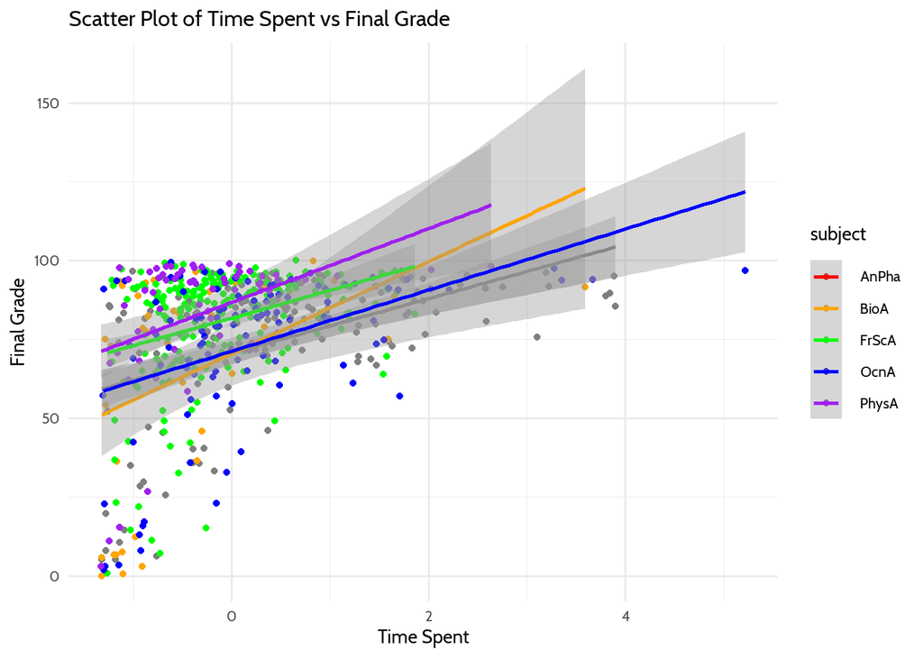

Fig. 2: Scatter Plot of Time Spent vs Final Grade

```r
dat %>%
  ggplot(aes(x=TimeSpent_std, y=final_grade, color=subject)) +
  geom_point() +
  # adding least-square regression lines
  geom_smooth(method = "lm") +
  # use data science in edu theme
  theme_dataedu() +
  # use red, orange, ..., purple as the colors for the points
  scale_color_manual(values=c("AnPha"="red",
                             "BioA" = "orange",
                             "FrScA" = "green",
                             "OcnA" = "blue",
                             "PhysA" = "purple")) +
  # use labs to create title, x, y labs
  labs(title = "Scatter Plot of Time Spent vs Final Grade",
       x = "Time Spent", y = "Final Grade") +
  # Increase font size of all text to at least 20
  theme(text = element_text(size = 20))
```

## Exercise 3

Incorporating the survey subscale scores into the prediction of final course grade from time spent and academic subject.

### Joining Data

Join the dat and survey_responses data files `gradebook <- leftjoin(dat, survey_responses, by="student_id")`

```r
# Join the dat and survey_responses data files
gradebook <- left_join(dat, survey_responses,
                       by = "student_id")
gradebook
```

```
## # A tibble: 603 × 27
##    course_id     subject semes…¹ section stude…² Grade…³ Grade…⁴ final…⁵ Point…⁶
##    <chr>         <chr>   <chr>   <chr>     <dbl> <chr>   <lgl>     <dbl>   <dbl>
##  1 AnPhA-S116-01 AnPhA   S116    01        60186 POINTS… NA         86.3       5
##  2 AnPhA-S116-01 AnPhA   S116    01        66693 POINTS… NA         93.8      24
##  3 AnPhA-S116-01 AnPhA   S116    01        66811 POINTS… NA         91.2      10
##  4 AnPhA-S116-01 AnPhA   S116    01        66862 POINTS… NA         59.8      15
##  5 AnPhA-S116-01 AnPhA   S116    01        67508 POINTS… NA         83.8       5
##  6 AnPhA-S116-01 AnPhA   S116    01        70532 POINTS… NA         93.6       5
##  7 AnPhA-S116-01 AnPhA   S116    01        77010 POINTS… NA         73.2      24
##  8 AnPhA-S116-01 AnPhA   S116    01        85249 POINTS… NA         86.9       5
##  9 AnPhA-S116-01 AnPhA   S116    01        85411 POINTS… NA         90.9      30
## 10 AnPhA-S116-01 AnPhA   S116    01        85583 POINTS… NA         91.7      24
## # … with 593 more rows, 18 more variables: Points_Earned <dbl>, Gender <chr>,
## #   q1 <dbl>, q2 <dbl>, q3 <dbl>, q4 <dbl>, q5 <dbl>, q6 <dbl>, q7 <dbl>,
## #   q8 <dbl>, q9 <dbl>, q10 <dbl>, TimeSpent <dbl>, TimeSpent_hours <dbl>,
## #   TimeSpent_std <dbl>, int <dbl>, pc <dbl>, uv <dbl>, and abbreviated
## #   variable names ¹semester, ²student_id, ³Gradebook_Item, ⁴Grade_Category,
## #   ⁵final_grade, ⁶Points_Possible
```

### Using Backward Elimination Model Selection Procedure to Get The Best Fitted Model

Fitting a model predicting final_grade from all variables (TimeSpent_std, subject, and pc, int, uv)

$$\hat{final\_grade} = \hat\beta_0 + \hat\beta_1(TimeSpent_std) +
\hat\beta_2(pc) + \hat\beta_3(int) + \hat\beta_4(uv) +
\hat\beta_5(subject) + \epsilon$$

```r
m_linear_1 <- lm(final_grade ~ TimeSpent_std + pc + int + uv + subject, data = gradebook)
tab_model(m_linear_1, title = "Table 3.1")
```

Table 3.1

|  | final grade |  |  |
| --- | --- | --- | --- |
| Predictors | Estimates | CI | p |
| (Intercept) | 76.71 | 63.14 – 90.28 | **<0.001** |
| TimeSpent std | 9.79 | 7.94 – 11.64 | **<0.001** |
| pc | -4.10 | -7.61 – -0.59 | **0.022** |
| int | 2.78 | -1.18 – 6.74 | 0.168 |
| uv | -1.43 | -4.59 – 1.74 | 0.376 |
| subject [BioA] | -1.49 | -9.17 – 6.19 | 0.703 |
| subject [FrScA] | 13.48 | 8.76 – 18.19 | **<0.001** |
| subject [OcnA] | 3.92 | -1.46 – 9.29 | 0.153 |
| subject [PhysA] | 17.82 | 11.44 – 24.20 | **<0.001** |
| Observations | 503 |  |  |
| R<sup>2</sup> / R<sup>2</sup> adjusted | 0.240 / 0.228 |  |  |

From Table 3.1 above, The model has an adjusted R^2 of 0.228 and the measure uv with p-value = 0.376 appears to be the least significant predictor of final grade after TimeSpent_std, subject, int and pc. This predictor will be dropped and the model is refitted below:

$$\hat{final\_grade} = \hat\beta_0 + \hat\beta_1(TimeSpent_std) +
\hat\beta_2(pc) + \hat\beta_3(int) + \hat\beta_4(subject) + \epsilon$$

```r
m_linear_2 <- lm(final_grade ~ TimeSpent_std + pc + int + subject, data = gradebook)
tab_model(m_linear_2, title = "Table 3.2")
```

Table 3.2

|  | final grade |  |  |
| --- | --- | --- | --- |
| Predictors | Estimates | CI | p |
| (Intercept) | 75.68 | 62.30 – 89.06 | **<0.001** |
| TimeSpent std | 9.81 | 7.96 – 11.66 | **<0.001** |
| pc | -4.49 | -7.89 – -1.09 | **0.010** |
| int | 2.09 | -1.56 – 5.73 | 0.262 |
| subject [BioA] | -1.50 | -9.18 – 6.18 | 0.701 |
| subject [FrScA] | 13.53 | 8.82 – 18.25 | **<0.001** |
| subject [OcnA] | 3.89 | -1.49 – 9.26 | 0.156 |
| subject [PhysA] | 17.92 | 11.55 – 24.29 | **<0.001** |
| Observations | 503 |  |  |
| R<sup>2</sup> / R<sup>2</sup> adjusted | 0.239 / 0.229 |  |  |

From Table 3.2 above The model has an adjusted R^2 of 0.229, and the p-value (p-value=0.262) of the “int” measure is greater than 0.05 suggesting that int is not a significant predictor of final grade after TimeSpent_std, subject and pc have been accounted for. As such we can drop this predictor and re-fit the model as follow:

$$\hat{final\_grade} = \hat\beta_0 + \hat\beta_1(TimeSpent_std) +
\hat\beta_2(pc) + \hat\beta_3(subject) + \epsilon$$

```r
m_linear_3 <- lm(final_grade ~ TimeSpent_std + pc + subject, data = gradebook)
tab_model(m_linear_3, title = "Table 3.3")
```

Table 3.3

|  | final grade |  |  |
| --- | --- | --- | --- |
| Predictors | Estimates | CI | p |
| (Intercept) | 79.90 | 69.29 – 90.50 | **<0.001** |
| TimeSpent std | 9.80 | 7.95 – 11.65 | **<0.001** |
| pc | -3.23 | -5.96 – -0.50 | **0.020** |
| subject [BioA] | -1.35 | -9.03 – 6.32 | 0.729 |
| subject [FrScA] | 13.54 | 8.84 – 18.25 | **<0.001** |
| subject [OcnA] | 3.89 | -1.48 – 9.26 | 0.155 |
| subject [PhysA] | 17.93 | 11.56 – 24.30 | **<0.001** |
| Observations | 504 |  |  |
| R<sup>2</sup> / R<sup>2</sup> adjusted | 0.237 / 0.228 |  |  |

Finally, the model showed that students grade is estimated by 9.80 points for every additional unit of time they spend on a course, after accounting for variations in subjects and “pc” measure.

### Creating the Residual vs FItted Plot

The block of code below plots a residual vs. Fitted plot which helps to assess whether the conditions of linearity and constant variance are met by our fitted model.

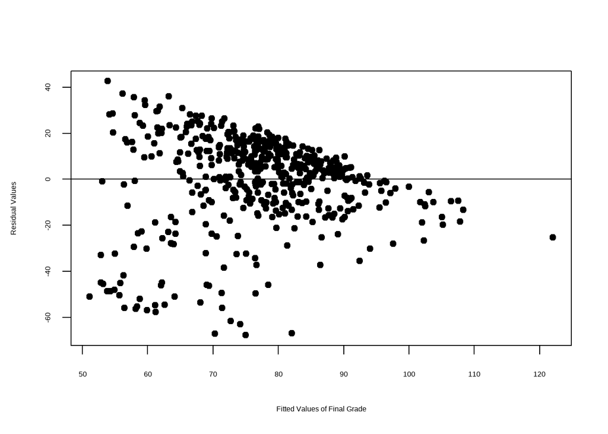

Fig 3.1: Residual vs Fitted Plot of Students Final Grades

```r
# getting the residual values
resids <- resid(m_linear_3)
# getting the fitted values
fits <- fitted(m_linear_3)
# plotting residual vs fitted values using base R plot function
plot(fits, resids,  pch=19, xlab="Fitted Values of Final Grade", ylab="Residual Values")
# setting intercept and slope as 0,0
abline(0, 0)
```

### Creating a Normal Plot using the qqnorm() function

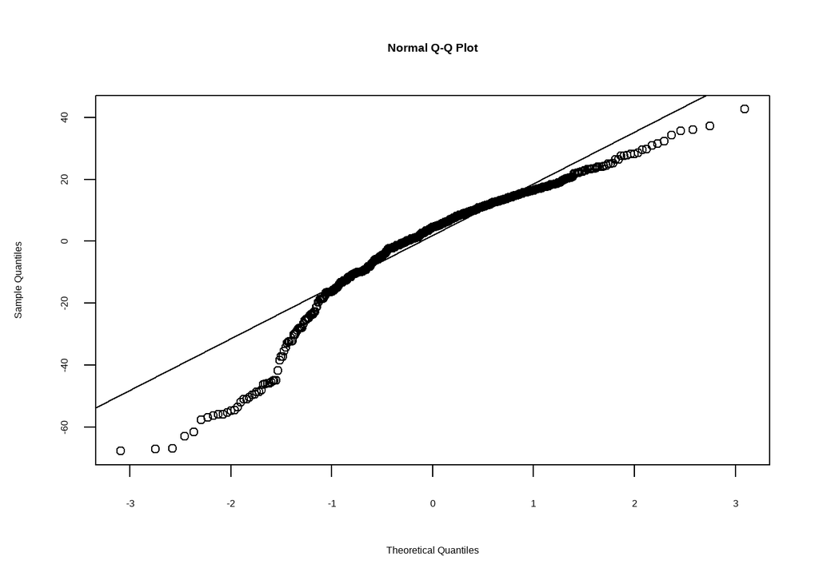

Fig. 3.2: Normal Plot of Residuals

```r
qqnorm(resids)
qqline(resids)
```

The normal plot of residuals above does not follow a linear pattern. As such, the condition of normally distributed error is not met. This is further supported by the skewness of QQ distribution in the histogram below.

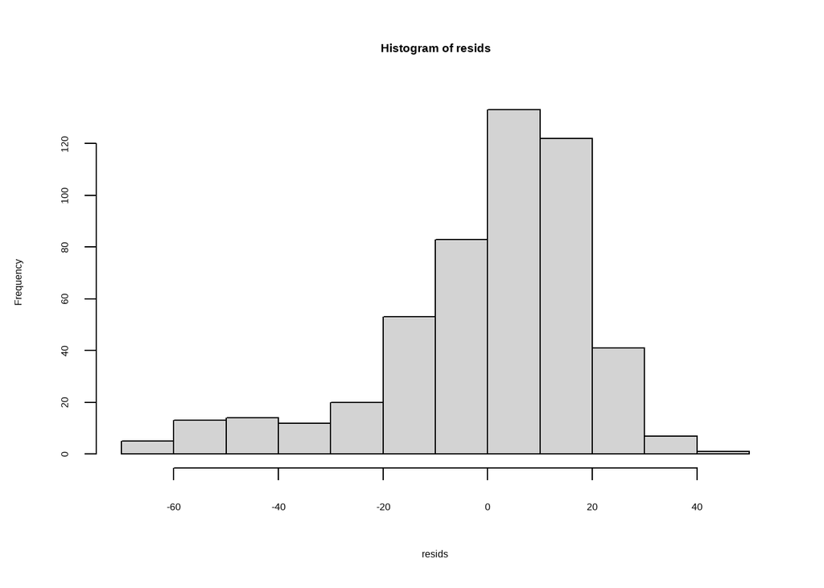

```r
hist(resids)
```